# IODS final project

Riku Laine

# Modelling exam scores with logistic regression

## Abstract

In this report I have analyzed the learning2014 data constructed by Kimmo Vehkalahti. Initially I thought that one’s attitude and willingness to connect the learned to the previously experienced would be the key factors in good exam performance but I was partially wrong. I seems that attitude makes the greatest impact and time managing skills the second greatest. Connecting the learned to one’s previous experience seems to have negative effects.

## Research question and hypothesis

I was interested in finding out what factors of people’s learning are the most connected to their final score. Could boundness in the course syllabus be somehow in connection with a low score or could good planning be the key to success? I concluded that logistic regression was the most fitting tool to answer this question.

I hypothesized that along with attitude, `RelatingIdeas` (relating ideas to one’s previous knowledge and experience) would affect the final score as it represents how much does a student ponder the things taught in class. And when one revises things learned it deepens their learning, as “repetitio est mater studiorum”.

## Data description

[The data](http://www.helsinki.fi/~kvehkala/JYTmooc/JYTOPKYS3-data.txt) was acquired from a study made by Kimmo Vehkalahti. The study included a questionnaire which was held in Fall 2014 for the participants of an introductory course to statistics (Johdatus yhteiskuntatilastotieteeseen) and it was funded by the Teachers’ Academy. The questionnaire itself had questions regarding for instance the students’ motivation, strategies in studying and general interest in statistics.

The variables – apart from gender and age – describe the following attributes of an individual (synthesized based on data from [here](http://www.psy.gla.ac.uk/~steve/dands/dandstable.html)<sup>1</sup> and [here](http://www.etl.tla.ed.ac.uk/questionnaires/scoringkey.pdf)<sup>2</sup>):

- `Attitude` – Respondent’s general attitude towards studying statistics
- `SeekingMeaning` – Intention to understand for oneself<sup>2</sup>
- `RelatingIdeas` – relating ideas (or things learned) to one’s previous knowledge and experience<sup>2</sup>
- `UseOfEvidence` – Examining the logic of arguments<sup>1</sup>
- `LackOfPurpose` – Not reflecting on purpose (why is this or that being done) or strategies<sup>2</sup>
- `UnrelatedMemorizing` – Memorising facts and procedures routinely<sup>2</sup>
- `SyllabusBoundness` – Concentrating only on what is required for assessment<sup>2</sup>
- `OrganizedStudying` – Preparing for classes and how organized is in studies
- `TimeManagement` – How good at managing one’s time.

### Data processing

The original data set consisted of 183 observations, but after [processing it](https://raw.githubusercontent.com/Riku-Laine/IODS-final/master/data/createLearningFP.R) only 166 observations remained due to the exclusion of individuals who had zero points from the final exam from not attending it. Processing the data, I constructed the variables for e.g. use of evidence and seeking meaning by the instructions in the [meta page](http://www.helsinki.fi/~kvehkala/JYTmooc/JYTOPKYS2-meta.txt) and named them as above. For instance, `SeekingMeaning` is the mean for the answers D03, D11, D19 and D27 which were answered in the 5-point [Likert scale](https://en.wikipedia.org/wiki/Likert_scale).

For the logistic regression, variable `HighPoints` is constructed to be true if the person received more points than the median of the group (23).

### The data visually

First I explored the data with a paired plot matrix to see possible trends and correlations between the variables of the data. Afterwards, I deepened my analysis with some variables of interest revealed by the plot matrix.

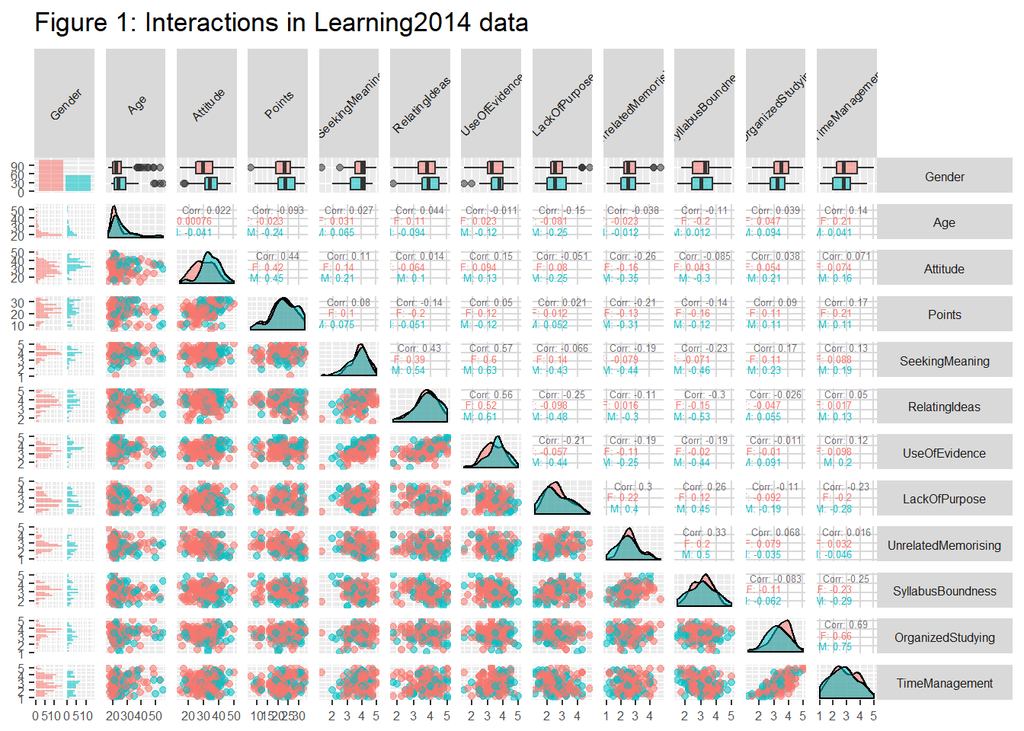

```r
learning2014 <- read.csv("~/GitHub/IODS-final/data/learning2014.csv")

ggpairs(learning2014[,-13], mapping = aes(col=Gender, alpha=0.1), lower = list(combo = wrap("facethist", bins = 20)),  upper = list(continuous = wrap(size = 1.7, mycor, sgnf=2)))+
    theme(strip.text = element_text(size=6),
                strip.text.y = element_text(angle=0),
                axis.text = element_text(size=6),
                strip.text.x = element_text(angle=45))+
    ggtitle("Figure 1: Interactions in Learning2014 data")
```

Distributions of the variables seem to be quite symmetrical, although most of the respondents are students and therefore it is not surprising that the inter-quartile range of age falls between 21 and 27 years. There are only minor differences between the genders, males seem to have a better attitude towards statistics as females appear to be more organized in their studies. Males’ better attitude towards mathematics have been shown in previous studies.

From figure 1 above it is visible that there are some quite strong correlations with some of the variables. For instance the variables of deep learning `OrganizedStudying` and `TimeManagement` have a correlation coefficient of $\rho \approx 0,7$ as the attitude of a student correlates with their points with a coefficient $\rho \approx 0,43$. Correlations are analyzed more thoroughly below figure 2.

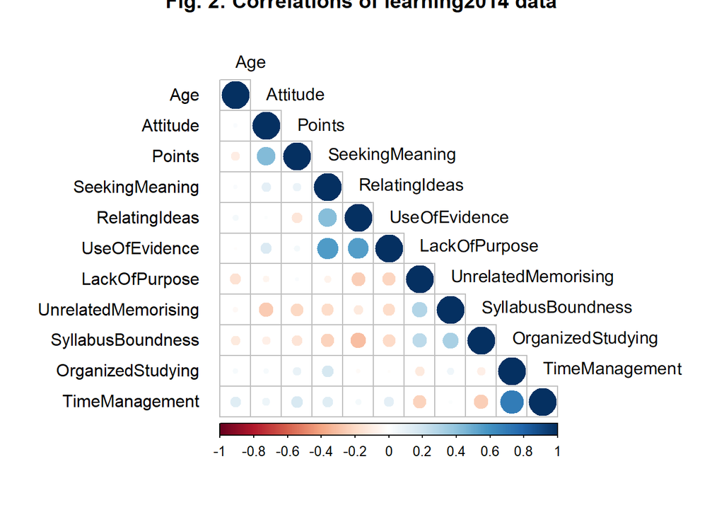

```r
corrplot(cor(learning2014[, -c(1, 13)]), type = "lower", diag = T, tl.col='black', tl.srt = 0.1, tl.offset = 1,
                 title = "Fig. 2: Correlations of learning2014 data")
```

From figure 2 it can be asserted that our variables correlate the most with the variables they comprise the original variables (such as Deep_adj) with. Also notable is the correlation with the students’ attitude and points from the final exam being approximately 0.44. This means better attitude associates with better performance in the exam. There are practically no other correlations that could cause collinearity in our regression model as all the others have an absolute value approximately smaller than 0.3.

### Gender differences in level of organization in studying and attitude toward statistics

In figure 1 there were some gender differences noted. Let’s look briefly into them. First, let us construct box plots of those variables and do a quick statistical test to assert the observed differences.

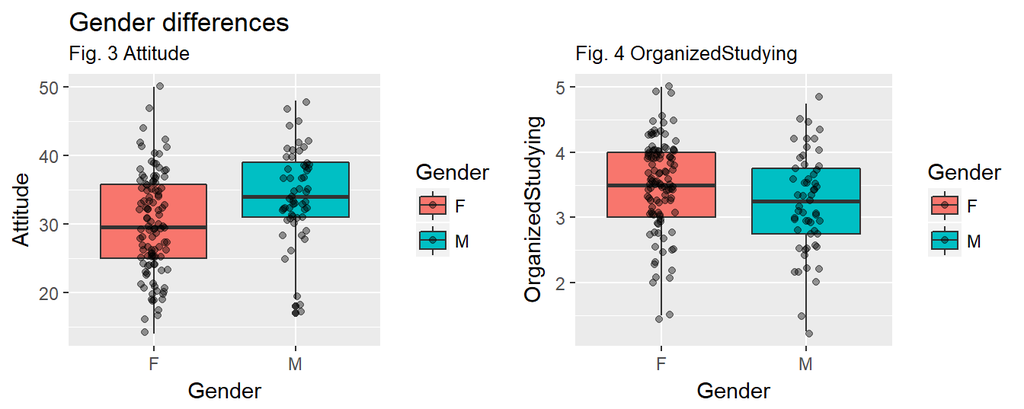

```r
p1 <- ggplot(learning2014, aes(x=Gender, y=Attitude, fill=Gender))+
    geom_boxplot()+
    geom_jitter(position=position_jitter(0.1), alpha=.4)+ggtitle("Gender differences", subtitle = "Fig. 3 Attitude")

p2 <- ggplot(learning2014, aes(x=Gender, y=OrganizedStudying, fill=Gender))+
    geom_boxplot()+
    geom_jitter(position=position_jitter(0.1), alpha=.4)+ggtitle("", subtitle = "Fig. 4 OrganizedStudying")

multiplot(p1, p2, cols=2)
```

It can be seen that men have higher attitude points, which is supported by Mann-Whitney U-test ($p \approx 1.1 \cdot 10^{-4}$). Females seem to be more organized (Mann-Whitney U, $p \approx 7.1 \cdot 10^{-3}$) in a statistically significant quantity. These differences have been noted in previous studies.

## Methods

### Logistic regression

As [NCBI](https://www.ncbi.nlm.nih.gov/pmc/articles/PMC1065119/) puts it, logistic regression “is a method for modelling the dependence of a binary response variable on one or more explanatory variables.” In our case we have the binary response variable of points gotten in the final exam; if one has a score higher than the median of points (23) they will have 1, as ones with a lower score get a zero. The regression model then attempts to estimate the dependent variable in the best fashion. The prediction $\textbf{Y}$ will be constructed as a linear combination of our explanatory values, such that a minimum amount of residual is created.

The model offers the impact of the explanatory variables as log odds ratios. By exponentiating them, the achieved “odds ratio can be used to quantify the relationship between X and Y. Odds higher than 1 mean that X is positively associated with ‘success’” as [Tuomo explained](https://tuomonieminen.github.io/Helsinki-Open-Data-Science/#/30).

### Other statistical tests used

#### Mann-Whitney U-test

Mann-Whitney U-test is a non-parametric alternative for the t-test. In other words, we do not have the assume that our variables are normally distributed. The test allows us to test “the null hypothesis that it is equally likely that a randomly selected value from one sample will be less than or greater than a randomly selected value from a second sample” ([Wikipedia](https://en.wikipedia.org/wiki/Mann%E2%80%93Whitney_U_test)). Fig. 5 shows that the distributions are quite normal in `Attitude` but it has been shown that Mann-Whitney doesn’t lose its statistical power compared to the t-test in such a quantity it would be beneficial to risk on the normality assumption.

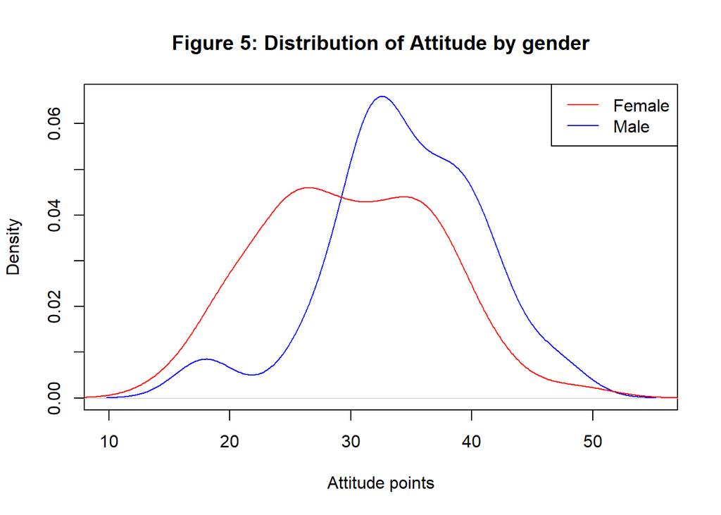

```r
plot(density(learning2014$Attitude[learning2014$Gender=='M']), col='blue', main="Figure 5: Distribution of Attitude by gender", xlab="Attitude points")
lines(density(learning2014$Attitude[learning2014$Gender=='F']), col='red')
legend("topright", col=c("red", "blue"), legend = c('Female', 'Male'), lty=1)
```

## Results

First I constructed logistic regression model over all the variables in the data to predict `HighScores`. Summary of the model can be seen below.

```r
model <- glm(HighPoints ~ Gender + Age + Attitude + SeekingMeaning + RelatingIdeas + UseOfEvidence + LackOfPurpose + UnrelatedMemorising + SyllabusBoundness + OrganizedStudying + TimeManagement, data = learning2014, family = "binomial")

summary(model)
```

```
##
## Call:
## glm(formula = HighPoints ~ Gender + Age + Attitude + SeekingMeaning +
##     RelatingIdeas + UseOfEvidence + LackOfPurpose + UnrelatedMemorising +
##     SyllabusBoundness + OrganizedStudying + TimeManagement, family = "binomial",
##     data = learning2014)
##
## Deviance Residuals:
##     Min       1Q   Median       3Q      Max
## -2.0293  -0.8736  -0.3831   0.8903   2.4360
##
## Coefficients:
##                     Estimate Std. Error z value Pr(>|z|)
## (Intercept)          0.82045    2.46496   0.333   0.7393
## GenderM             -0.13485    0.44215  -0.305   0.7604
## Age                 -0.01937    0.02393  -0.810   0.4182
## Attitude             0.13664    0.03177   4.301  1.7e-05 ***
## SeekingMeaning      -0.09321    0.40025  -0.233   0.8159
## RelatingIdeas       -0.60260    0.32922  -1.830   0.0672 .
## UseOfEvidence       -0.56547    0.42538  -1.329   0.1837
## LackOfPurpose        0.38188    0.28672   1.332   0.1829
## UnrelatedMemorising -0.49226    0.31330  -1.571   0.1161
## SyllabusBoundness   -0.27975    0.30440  -0.919   0.3581
## OrganizedStudying   -0.43757    0.37308  -1.173   0.2409
## TimeManagement       0.83544    0.30524   2.737   0.0062 **
## ---
## Signif. codes:  0 '***' 0.001 '**' 0.01 '*' 0.05 '.' 0.1 ' ' 1
##
## (Dispersion parameter for binomial family taken to be 1)
##
##     Null deviance: 228.58  on 165  degrees of freedom
## Residual deviance: 178.25  on 154  degrees of freedom
## AIC: 202.25
##
## Number of Fisher Scoring iterations: 4
```

From the above summary it can be concluded that only the students attitude towards statistics and time managing skills matter in regard of performance in the final exam. Residuals of the model are somewhat symmetrically distributed. In table 1 below are the regression coefficients, 95% confidence intervals and p-values for our covariates. From there it is seen, that for every attitude point gained, the probability of success gets significantly greater (OR 1.15, 95% CI from 1.08 to 1.22, $p \approx 1.70\cdot 10^{-5}$). Also time management is playing a key role in determining final exam scores. Its OR estimate is approximately 2,3, but it was scaled from 1 to 5 as attitude ranged from 14 to 50.

```r
tableLogReg <- cbind(Coefficient = coef(model), confint(model)) %>% exp %>% round(., digits = 4)
tableLogReg <- cbind(tableLogReg, `P-value` = round(summary(model)$coefficients[, 4], digits = 4))
kable(tableLogReg, caption = "Table 1: Regression coefficients, 95% confidence intervals and p-values")
```

Table 1: Regression coefficients, 95% confidence intervals and p-values

|  | Coefficient | 2.5 % | 97.5 % | P-value |
| --- | --- | --- | --- | --- |
| (Intercept) | 2.2715 | 0.0192 | 321.0678 | 0.7393 |
| GenderM | 0.8738 | 0.3643 | 2.0800 | 0.7604 |
| Age | 0.9808 | 0.9346 | 1.0276 | 0.4182 |
| Attitude | 1.1464 | 1.0805 | 1.2246 | 0.0000 |
| SeekingMeaning | 0.9110 | 0.4126 | 2.0013 | 0.8159 |
| RelatingIdeas | 0.5474 | 0.2817 | 1.0366 | 0.0672 |
| UseOfEvidence | 0.5681 | 0.2416 | 1.2950 | 0.1837 |
| LackOfPurpose | 1.4650 | 0.8416 | 2.6065 | 0.1829 |
| UnrelatedMemorising | 0.6112 | 0.3248 | 1.1171 | 0.1161 |
| SyllabusBoundness | 0.7560 | 0.4130 | 1.3730 | 0.3581 |
| OrganizedStudying | 0.6456 | 0.3058 | 1.3316 | 0.2409 |
| TimeManagement | 2.3058 | 1.2907 | 4.3012 | 0.0062 |

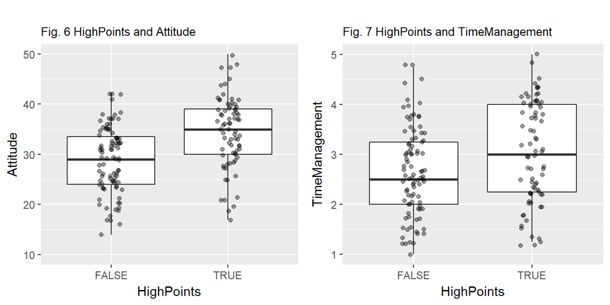

```r
p3 <- ggplot(learning2014, aes(x=HighPoints, y=Attitude))+
    geom_boxplot()+ylim(10,50)+
    geom_jitter(position=position_jitter(0.1), alpha=.4)+ggtitle("", subtitle = "Fig. 6 HighPoints and Attitude")

p4 <- ggplot(learning2014, aes(x=HighPoints, y=TimeManagement))+
    geom_boxplot()+
    geom_jitter(position=position_jitter(0.1), alpha=.4)+ggtitle("", subtitle = "Fig. 7 HighPoints and TimeManagement")

multiplot(p3, p4, cols=2)
```

As negative results it can be noted that for instance gender and age had no effect on scoring. Connecting ideas to the previously learned or experienced might be an interesting variable to analyze in the following studies. It seem quite odd how it seems to be (in a non-significant matter) in contact with poorer performance in final exam as the OR estimate with its intervals are close to be under 1.

### Validation analysis

For validation analysis, I will perform likelihood ratio tests to see if a reduced model would be more suitable to model the exam scores and in addition i will cross tabulate the predicted values of our model to the actual to see the predictive power of it.

Initially our model was called in form *HighPoints ~ Gender + Age + Attitude + SeekingMeaning + RelatingIdeas + UseOfEvidence + LackOfPurpose + UnrelatedMemorising + SyllabusBoundness + OrganizedStudying + TimeManagement*, but in the summary of the formula it was seen that some of the arguments, especially Gender, Age and SeekingMeaning weren’t at all significant so I removed them from the model and constructed another which I proceeded to test against the first model with a likelihood ratio test. The test returned non-significant ($p > 0.05$) so those variables were non-significant for our model. After a brief exploration, it occurred that there were no significant differences in between models with all variables and the model with only `Attitude`, `RelatingIdeas` and `TimeManagement` as seen below.

```r
model2 <- glm(HighPoints ~ Attitude + RelatingIdeas + TimeManagement, data = learning2014, family = "binomial")
anova(model, model2, test = "LRT")
```

```
## Analysis of Deviance Table
##
## Model 1: HighPoints ~ Gender + Age + Attitude + SeekingMeaning + RelatingIdeas +
##     UseOfEvidence + LackOfPurpose + UnrelatedMemorising + SyllabusBoundness +
##     OrganizedStudying + TimeManagement
## Model 2: HighPoints ~ Attitude + RelatingIdeas + TimeManagement
##   Resid. Df Resid. Dev Df Deviance Pr(>Chi)
## 1       154     178.25
## 2       162     187.69 -8  -9.4306   0.3073
```

Below is also a similar validation analysis which was done in DataCamp. First we predicted the values of HighPoints and the cross tabulated them with the actual values. So it was concluded that our model predicted success approximately 73% right. There were a total of 45 miss-predictions, but partly they might have arisen from the fact that there were 13 students with the median score 23. All in all there were 34 students in one-point radius from the median (meaning [22,24]).

```r
# predict the probability
probabilities <- predict(model, type = "response")

learning2014  <- mutate(learning2014, probability = probabilities)

learning2014  <- mutate(learning2014, prediction = probability > 0.5)

# tabulating the target variable versus the predictions
table(HighPoints = learning2014$HighPoints, Prediction = learning2014$prediction)
```

```
##           Prediction
## HighPoints FALSE TRUE
##      FALSE    69   22
##      TRUE     23   52
```

## Conclusions and discussion

Reflecting the original hypothesis, it can be concluded that attitude has a significant effect on the final results. Thinking about relating ideas didn’t have a significant effect but it had a p-value of approximately 0.067 and an OR estimate of 0.54 suggesting that connecting the learned to one’s previous knowledge would deteriorate the learning results.

TimeManagement arose as an unprecedented effect. It had the second most significant effect on exam scores. Although if you read the [scoring key](http://www.etl.tla.ed.ac.uk/questionnaires/scoringkey.pdf), you see that time management has answers such as *I’m pretty good at getting down to work whenever I need to* and * I work steadily during the course, rather than just leaving things until the last minute*. The questions might imply to answer regarding only the specific course and thereby have some correlation to motivation which would then affect the final score. This theory has some basis when looking at Figure 8: the ones with high points seem to be in the top right corner of the plot with high time management skills and good attitude, as the ones with bad attitude, poor time management and low score fall in the lower left corner of the plot.

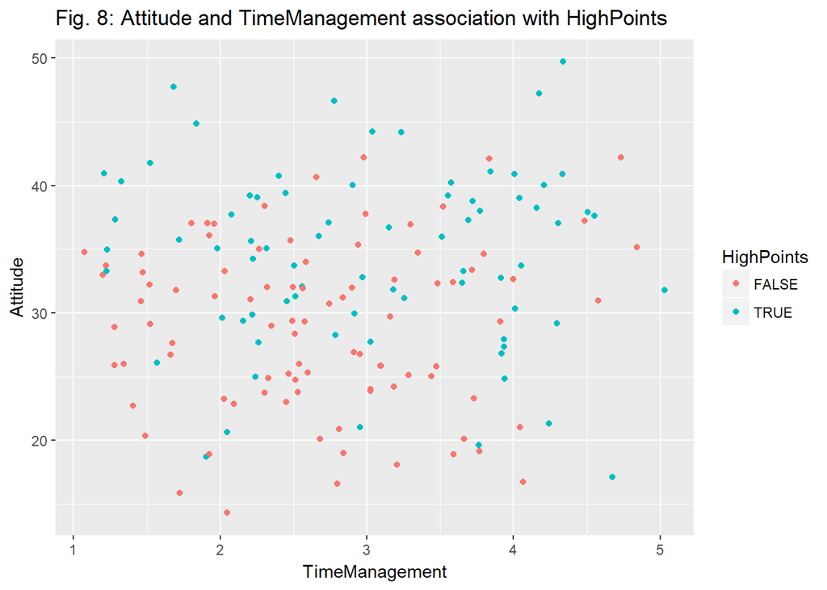

```r
ggplot(learning2014, aes(x=TimeManagement, y=Attitude))+geom_jitter(aes(col=HighPoints))+ggtitle("Fig. 8: Attitude and TimeManagement association with HighPoints")
```

A better suiting model could have been chosen for the analysis. Perhaps some regular general linear model would have been more fitting, so that we could have gotten more power out of our continuous response variable. Due to the lack of my time I didn’t perform cross validation but it would have been a nice touch in the assertation of the model.